# Unsupervised Project 6.jstatter

Jennifer Statter

#### Background:

AllLife Bank wants to focus on its credit card customer base in the next financial year. They have been advised by their marketing research team, that the penetration in the market can be improved. Based on this input, the Marketing team proposes to run personalized campaigns to target new customers as well as upsell to existing customers. Another insight from the market research was that the customers perceive the support services of the back poorly. Based on this, the Operations team wants to upgrade the service delivery model, to ensure that customer queries are resolved faster. Head of Marketing and Head of Delivery both decide to reach out to the Data Science team for help

#### Objective

To identify different segments in the existing customer, based on their spending patterns as well as past interaction with the bank, using clustering algorithms, and provide recommendations to the bank on how to better market to and service these customers.

#### Feature Dictionary:

- Sl_No: Primary key of the records
- Customer Key: Customer identification number
- Average Credit Limit: Average credit limit of each customer for all credit cards
- Total credit cards: Total number of credit cards possessed by the customer
- Total visits bank: Total number of visits that customer made (yearly) personally to the bank
- Total visits online: Total number of visits or online logins made by the customer (yearly)
- Total calls made: Total number of calls made by the customer to the bank or its customer service department (yearly)

### Interpretation:

#### Marketing Statement:

The Bank wants to upsell credit cards with the goal to increase the amount of responsible customers that earned a higher credit card limit. Therefore, our target group is Total credit cards.

#### Delivery Statement:

Use Total credit cards in relation to bank visits, visits online, and calls to make a decision on what service to focus on.

```python
import pandas as pd
import numpy as np

import matplotlib.pylab as plt
%matplotlib inline

import seaborn as sns
from sklearn.model_selection  import train_test_split
from sklearn.cluster import KMeans

# to compute distances
from scipy.spatial.distance import pdist
from scipy.spatial.distance import cdist

from sklearn.metrics import silhouette_score

# to perform hierarchical clustering, compute cophenetic correlation, and create dendrograms
from sklearn.cluster import AgglomerativeClustering
from scipy.cluster.hierarchy import dendrogram, linkage, cophenet

from scipy.stats import zscore

data = pd.read_csv("Credit+Card+Customer+Data.csv")
data.dtypes

# To supress warnings
import warnings

warnings.filterwarnings("ignore")

# This will help in making the Python code more structured automatically (good coding practice)
%load_ext nb_black
```

```python
data.shape
```

```
(660, 7)
```

```python
data.head()
```

|  | Sl_No | Customer Key | Avg_Credit_Limit | Total_Credit_Cards | Total_visits_bank | Total_visits_online | Total_calls_made |
| --- | --- | --- | --- | --- | --- | --- | --- |
| 0 | 1 | 87073 | 100000 | 2 | 1 | 1 | 0 |
| 1 | 2 | 38414 | 50000 | 3 | 0 | 10 | 9 |
| 2 | 3 | 17341 | 50000 | 7 | 1 | 3 | 4 |
| 3 | 4 | 40496 | 30000 | 5 | 1 | 1 | 4 |
| 4 | 5 | 47437 | 100000 | 6 | 0 | 12 | 3 |

```python
# checking for duplicates
data[data.duplicated()].count()
```

```
Sl_No                  0
Customer Key           0
Avg_Credit_Limit       0
Total_Credit_Cards     0
Total_visits_bank      0
Total_visits_online    0
Total_calls_made       0
dtype: int64
```

```python
# drop the Sl_No. column as it does not add any value to the analysis
data.drop("Sl_No", axis=1, inplace=True)
```

```python
# drop the Customer Key. column as it does not add any value to the analysis
data.drop("Customer Key", axis=1, inplace=True)
```

```python
data.shape
```

```
(660, 5)
```

```python
data.info()
```

```
<class 'pandas.core.frame.DataFrame'>
RangeIndex: 660 entries, 0 to 659
Data columns (total 5 columns):
 #   Column               Non-Null Count  Dtype
---  ------               --------------  -----
 0   Avg_Credit_Limit     660 non-null    int64
 1   Total_Credit_Cards   660 non-null    int64
 2   Total_visits_bank    660 non-null    int64
 3   Total_visits_online  660 non-null    int64
 4   Total_calls_made     660 non-null    int64
dtypes: int64(5)
memory usage: 25.9 KB
```

- I have no dupicates. I dropped all useless columns. My memory usage is small and manageable. I have no nulls. All my data types are int64. I am now ready to do outlier treatment.

#### Outlier Identification Using Univariate Analysis

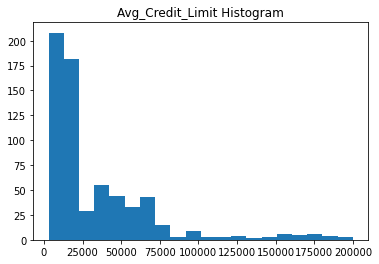

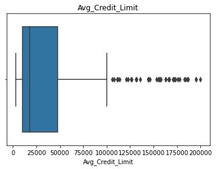

```python
plt.hist(data["Avg_Credit_Limit"], 20)
plt.title("Avg_Credit_Limit Histogram")
plt.show()

sns.boxplot(data["Avg_Credit_Limit"])
plt.title("Avg_Credit_Limit")
plt.show()
```

- Avg_Credit_Limit is right-scewed.

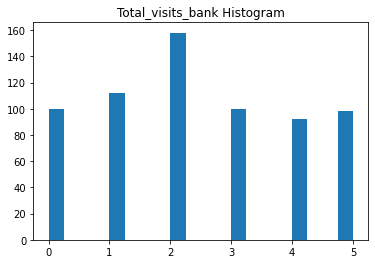

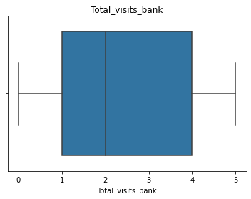

```python
plt.hist(data["Total_visits_bank"], 20)
plt.title("Total_visits_bank Histogram")
plt.show()

sns.boxplot(data["Total_visits_bank"])
plt.title("Total_visits_bank")
plt.show()
```

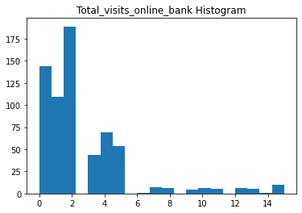

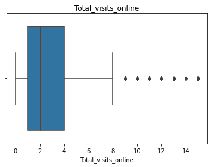

```python
plt.hist(data["Total_visits_online"], 20)
plt.title("Total_visits_online_bank Histogram")
plt.show()

sns.boxplot(data["Total_visits_online"])
plt.title("Total_visits_online")
plt.show()
```

- Visits Online are right-scewed.

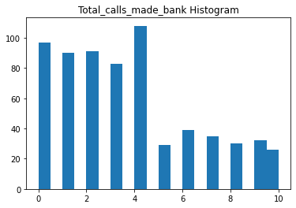

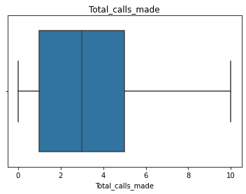

```python
plt.hist(data["Total_calls_made"], 20)
plt.title("Total_calls_made_bank Histogram")
plt.show()

sns.boxplot(data["Total_calls_made"])
plt.title("Total_calls_made")
plt.show()
```

- Calls made are right-scewed slightly

There will be no outlier treatment because we are dealing with moneny for credit card limit. However, there is a need for down scaling the credit card limit column because the rest of the columns are less then 15 units. Since I will be down scaling it, I will need it to be repesented by a float to account for the hundreds and thousands of dollers.

```python
# function to plot a boxplot and a histogram along the same scale.


def histogram_boxplot(data, feature, figsize=(12, 7), kde=False, bins=None):
    """
    Boxplot and histogram combined

    data: dataframe
    feature: dataframe column
    figsize: size of figure (default (12,7))
    kde: whether to the show density curve (default False)
    bins: number of bins for histogram (default None)
    """
    f2, (ax_box2, ax_hist2) = plt.subplots(
        nrows=2,  # Number of rows of the subplot grid= 2
        sharex=True,  # x-axis will be shared among all subplots
        gridspec_kw={"height_ratios": (0.25, 0.75)},
        figsize=figsize,
    )  # creating the 2 subplots
    sns.boxplot(
        data=data, x=feature, ax=ax_box2, showmeans=True, color="violet"
    )  # boxplot will be created and a star will indicate the mean value of the column
    sns.histplot(
        data=data, x=feature, kde=kde, ax=ax_hist2, bins=bins, palette="winter"
    ) if bins else sns.histplot(
        data=data, x=feature, kde=kde, ax=ax_hist2
    )  # For histogram
    ax_hist2.axvline(
        data[feature].mean(), color="green", linestyle="--"
    )  # Add mean to the histogram
    ax_hist2.axvline(
        data[feature].median(), color="black", linestyle="-"
    )  # Add median to the histogram
```

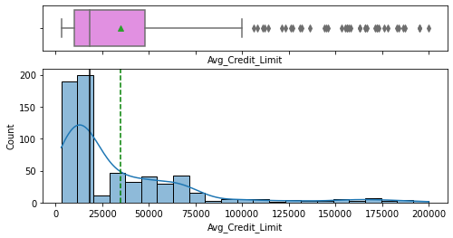

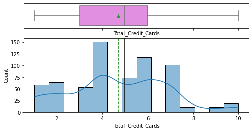

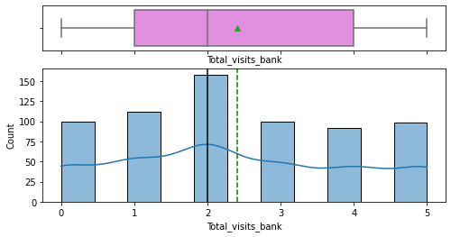

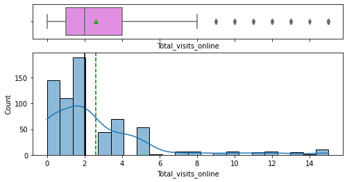

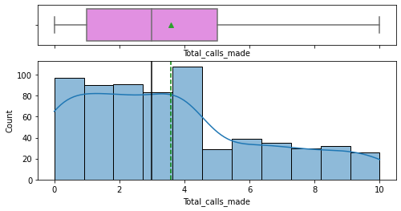

```python
# selecting all numerical columns
num_col = data.select_dtypes(include=np.number).columns.tolist()

for item in num_col:
    histogram_boxplot(data, item, kde=True, figsize=(8, 4))
```

```python
# function to create labeled barplots


def labeled_barplot(data, feature, perc=False, n=None):
    """
    Barplot with percentage at the top

    data: dataframe
    feature: dataframe column
    perc: whether to display percentages instead of count (default is False)
    n: displays the top n category levels (default is None, i.e., display all levels)
    """

    total = len(data[feature])  # length of the column
    count = data[feature].nunique()
    if n is None:
        plt.figure(figsize=(count + 1, 5))
    else:
        plt.figure(figsize=(n + 1, 5))

    plt.xticks(rotation=90, fontsize=15)
    ax = sns.countplot(
        data=data,
        x=feature,
        palette="Paired",
        order=data[feature].value_counts().index[:n].sort_values(),
    )

    for p in ax.patches:
        if perc == True:
            label = "{:.1f}%".format(
                100 * p.get_height() / total
            )  # percentage of each class of the category
        else:
            label = p.get_height()  # count of each level of the category

        x = p.get_x() + p.get_width() / 2  # width of the plot
        y = p.get_height()  # height of the plot

        ax.annotate(
            label,
            (x, y),
            ha="center",
            va="center",
            size=12,
            xytext=(0, 5),
            textcoords="offset points",
        )  # annotate the percentage

    plt.show()  # show the plot
```

```python
# function to create labeled barplots


def labeled_barplot_scaled(DataScaled, feature, perc=False, n=None):
    """
    Barplot with percentage at the top

    data: dataframe
    feature: dataframe column
    perc: whether to display percentages instead of count (default is False)
    n: displays the top n category levels (default is None, i.e., display all levels)
    """

    total = len(data[feature])  # length of the column
    count = data[feature].nunique()
    if n is None:
        plt.figure(figsize=(count + 1, 5))
    else:
        plt.figure(figsize=(n + 1, 5))

    plt.xticks(rotation=90, fontsize=15)
    ax = sns.countplot(
        DataScaled=DataScaled,
        x=feature,
        palette="Paired",
        order=data[feature].value_counts().index[:n].sort_values(),
    )

    for p in ax.patches:
        if perc == True:
            label = "{:.1f}%".format(
                100 * p.get_height() / total
            )  # percentage of each class of the category
        else:
            label = p.get_height()  # count of each level of the category

        x = p.get_x() + p.get_width() / 2  # width of the plot
        y = p.get_height()  # height of the plot

        ax.annotate(
            label,
            (x, y),
            ha="center",
            va="center",
            size=12,
            xytext=(0, 5),
            textcoords="offset points",
        )  # annotate the percentage

    plt.show()  # show the plot
```

[figure not shown]

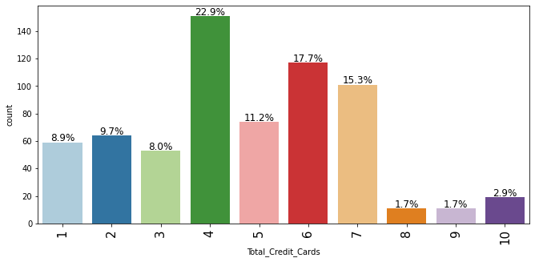

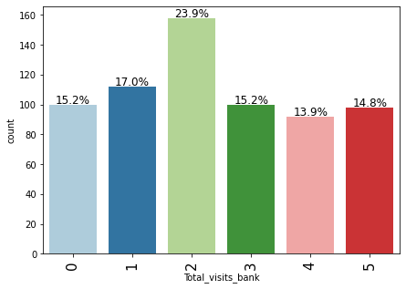

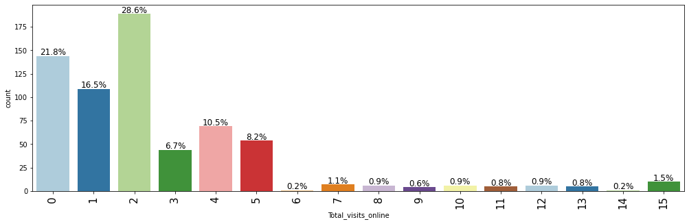

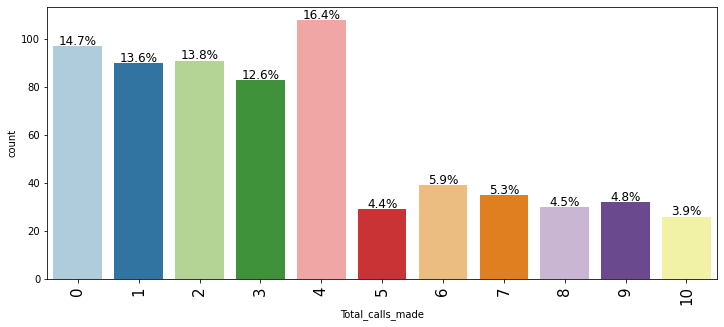

```python
for item in num_col:
    labeled_barplot(data, item, perc=True)
```

#### Scaleing

```python
# Convert features to float
data = data.astype("float64")
```

```python
data.info()
```

```
<class 'pandas.core.frame.DataFrame'>
RangeIndex: 660 entries, 0 to 659
Data columns (total 5 columns):
 #   Column               Non-Null Count  Dtype
---  ------               --------------  -----
 0   Avg_Credit_Limit     660 non-null    float64
 1   Total_Credit_Cards   660 non-null    float64
 2   Total_visits_bank    660 non-null    float64
 3   Total_visits_online  660 non-null    float64
 4   Total_calls_made     660 non-null    float64
dtypes: float64(5)
memory usage: 25.9 KB
```

- The memory usage was not increased when converting to a float.

I want to better understand my quartiles before scaling down the whole dataframe so it can be used as a reference when interpretating the scaled data.

```python
data.describe().T
```

|  | count | mean | std | min | 25% | 50% | 75% | max |
| --- | --- | --- | --- | --- | --- | --- | --- | --- |
| Avg_Credit_Limit | 660.0 | 34574.242424 | 37625.487804 | 3000.0 | 10000.0 | 18000.0 | 48000.0 | 200000.0 |
| Total_Credit_Cards | 660.0 | 4.706061 | 2.167835 | 1.0 | 3.0 | 5.0 | 6.0 | 10.0 |
| Total_visits_bank | 660.0 | 2.403030 | 1.631813 | 0.0 | 1.0 | 2.0 | 4.0 | 5.0 |
| Total_visits_online | 660.0 | 2.606061 | 2.935724 | 0.0 | 1.0 | 2.0 | 4.0 | 15.0 |
| Total_calls_made | 660.0 | 3.583333 | 2.865317 | 0.0 | 1.0 | 3.0 | 5.0 | 10.0 |

```python
DataAttr = data
DataAttr.head()
```

|  | Avg_Credit_Limit | Total_Credit_Cards | Total_visits_bank | Total_visits_online | Total_calls_made |
| --- | --- | --- | --- | --- | --- |
| 0 | 100000.0 | 2.0 | 1.0 | 1.0 | 0.0 |
| 1 | 50000.0 | 3.0 | 0.0 | 10.0 | 9.0 |
| 2 | 50000.0 | 7.0 | 1.0 | 3.0 | 4.0 |
| 3 | 30000.0 | 5.0 | 1.0 | 1.0 | 4.0 |
| 4 | 100000.0 | 6.0 | 0.0 | 12.0 | 3.0 |

```python
# Scaling Whole Dataframe
DataScaled = DataAttr.apply(zscore)
DataScaled.head(10)
```

|  | Avg_Credit_Limit | Total_Credit_Cards | Total_visits_bank | Total_visits_online | Total_calls_made |
| --- | --- | --- | --- | --- | --- |
| 0 | 1.740187 | -1.249225 | -0.860451 | -0.547490 | -1.251537 |
| 1 | 0.410293 | -0.787585 | -1.473731 | 2.520519 | 1.891859 |
| 2 | 0.410293 | 1.058973 | -0.860451 | 0.134290 | 0.145528 |
| 3 | -0.121665 | 0.135694 | -0.860451 | -0.547490 | 0.145528 |
| 4 | 1.740187 | 0.597334 | -1.473731 | 3.202298 | -0.203739 |
| 5 | -0.387644 | -0.787585 | -1.473731 | -0.547490 | 1.542593 |
| 6 | 1.740187 | 0.135694 | -1.473731 | 2.861408 | -0.553005 |
| 7 | -0.520633 | -0.787585 | -1.473731 | -0.547490 | -0.902271 |
| 8 | -0.786612 | -1.249225 | -1.473731 | -0.206600 | -0.553005 |
| 9 | -0.839808 | -0.325946 | -1.473731 | -0.547490 | 1.193326 |

#### Bivariate analysis Using Scaled Dataframe

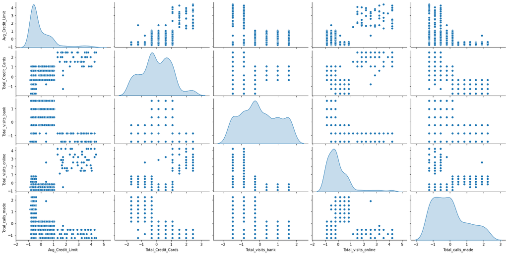

```python
# importing seaborn for statistical plots
sns.pairplot(DataScaled, height=2, aspect=2, diag_kind="kde")
```

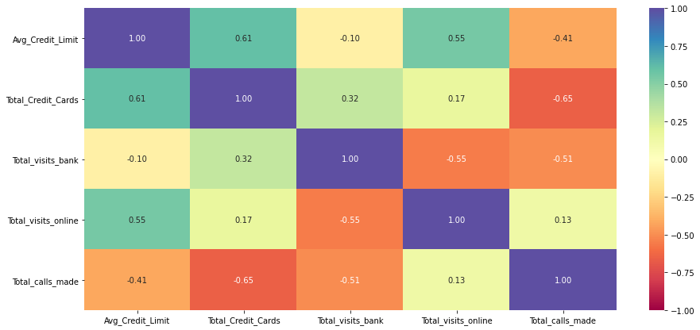

```python
# heat map using scaled data.
plt.figure(figsize=(15, 7))
sns.heatmap(DataScaled.corr(), annot=True, vmin=-1, vmax=1, fmt=".2f", cmap="Spectral")
plt.show()
```

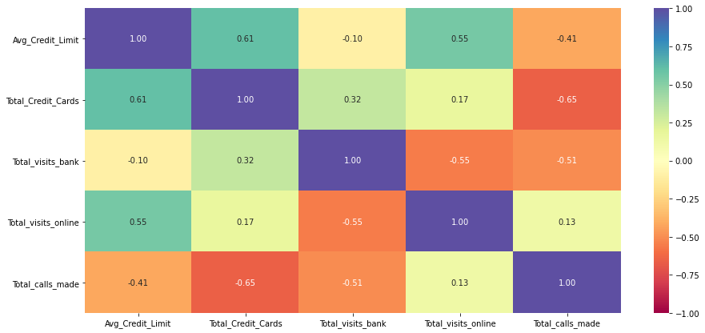

```python
# heat map using unscaled data
plt.figure(figsize=(15, 7))
sns.heatmap(data.corr(), annot=True, vmin=-1, vmax=1, fmt=".2f", cmap="Spectral")
plt.show()
```

- According to the heatmaps, Scaling did not change the correlation of any features
- Total Credit Card limit has a high correlation with Total Credit Cards and Total Visits Online. However, Total Credit Cards and Total Visits Online have a low correlation with eachother.
- Total Cards has a high negative relationship with total calls made and a positive correlation with visiting the bank.
- Total visits online has high negative correlation with visiting the bank and a weak positive correlation with total calls.
- Total calls made has a negative correlation with Credit Card Limit and a high negative correlation with total cards and total bank visits. It only has a positive relationship with visits online.

### EDA Summary:

The dataframe was scaled because money is a much bigger scale than customer service and card ownership features. No outliers where removed. There were no duplicates or nulls.

- Happy customers with more credit cards have a higher credit card limit and call less often.
- The more a customer calls the less likely they own a card.
- Customers with high credit card limits do most of their banking online and are also less likely to call and visit the bank.
- Credit card limit has a higher correlation with online visits than the amount of credit cards has.

It it is safe to assume the most unsatisfied customers call more often.

- People that vist the bank more often are more likely to own more credit cards.
- Customers with more credit cards that have lower credit limits perfer to go to the bank for service.

Upselling at the bank is more succesful than selling online.

### K-Means Clustering and Cluster Profiling

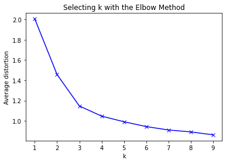

```python
# Finding optimal no. of clusters
from scipy.spatial.distance import cdist

clusters = range(1, 10)
meanDistortions = []

for k in clusters:
    model = KMeans(n_clusters=k)
    model.fit(DataScaled)
    prediction = model.predict(DataScaled)
    meanDistortions.append(
        sum(np.min(cdist(DataScaled, model.cluster_centers_, "euclidean"), axis=1))
        / DataScaled.shape[0]
    )


plt.plot(clusters, meanDistortions, "bx-")
plt.xlabel("k")
plt.ylabel("Average distortion")
plt.title("Selecting k with the Elbow Method")
```

- 3 is the correct amount of clusters based off the elbow curve above.

#### Silhouette Score

```
For n_clusters = 2, silhouette score is 0.41842496663215445
For n_clusters = 3, silhouette score is 0.5157182558881063
For n_clusters = 4, silhouette score is 0.3556670619372605
For n_clusters = 5, silhouette score is 0.2723911235693706
For n_clusters = 6, silhouette score is 0.2555743483456167
For n_clusters = 7, silhouette score is 0.24857211535274673
For n_clusters = 8, silhouette score is 0.22756437271245886
For n_clusters = 9, silhouette score is 0.22440496174070906
```

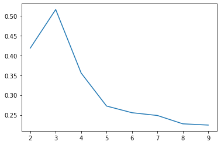

```python
sil_score = []
cluster_list = list(range(2, 10))
for n_clusters in cluster_list:
    clusterer = KMeans(n_clusters=n_clusters)
    preds = clusterer.fit_predict((DataScaled))
    # centers = clusterer.cluster_centers_
    score = silhouette_score(DataScaled, preds)
    sil_score.append(score)
    print("For n_clusters = {}, silhouette score is {}".format(n_clusters, score))

plt.plot(cluster_list, sil_score)
```

- From the silhouette scores, it seems that 3 is a good value of k because it is the highest point before dipping on the graph.

```python
kmeans = KMeans(n_clusters=3, random_state=0)
kmeans.fit(DataScaled)
```

```
KMeans(n_clusters=3, random_state=0)
```

```python
# adding kmeans cluster labels to the original dataframe
data["K_means_segments"] = kmeans.labels_
```

```python
cluster_profile = data.groupby("K_means_segments").mean()
```

```python
cluster_profile["count_in_each_segment"] = (
    data.groupby("K_means_segments")["Total_Credit_Cards"].count().values
)
```

```python
# let's display cluster profiles
cluster_profile.style.highlight_max(color="lightgreen", axis=0)
```

| K_means_segments | Avg_Credit_Limit | Total_Credit_Cards | Total_visits_bank | Total_visits_online | Total_calls_made | count_in_each_segment |
| --- | --- | --- | --- | --- | --- | --- |
| 0 | 33782.383420 | 5.515544 | 3.489637 | 0.981865 | 2.000000 | 386 |
| 1 | 12174.107143 | 2.410714 | 0.933036 | 3.553571 | 6.870536 | 224 |
| 2 | 141040.000000 | 8.740000 | 0.600000 | 10.900000 | 1.080000 | 50 |

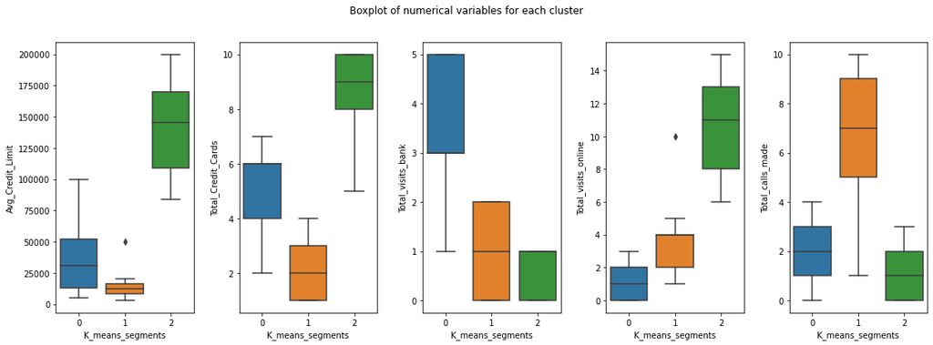

```python
fig, axes = plt.subplots(1, 5, figsize=(16, 6))
fig.suptitle("Boxplot of numerical variables for each cluster")
counter = 0
for ii in range(5):
    sns.boxplot(ax=axes[ii], y=data[num_col[counter]], x=data["K_means_segments"])
    counter = counter + 1

fig.tight_layout(pad=2.0)
```

```python
data.describe().T
```

|  | count | mean | std | min | 25% | 50% | 75% | max |
| --- | --- | --- | --- | --- | --- | --- | --- | --- |
| Avg_Credit_Limit | 660.0 | 34574.242424 | 37625.487804 | 3000.0 | 10000.0 | 18000.0 | 48000.0 | 200000.0 |
| Total_Credit_Cards | 660.0 | 4.706061 | 2.167835 | 1.0 | 3.0 | 5.0 | 6.0 | 10.0 |
| Total_visits_bank | 660.0 | 2.403030 | 1.631813 | 0.0 | 1.0 | 2.0 | 4.0 | 5.0 |
| Total_visits_online | 660.0 | 2.606061 | 2.935724 | 0.0 | 1.0 | 2.0 | 4.0 | 15.0 |
| Total_calls_made | 660.0 | 3.583333 | 2.865317 | 0.0 | 1.0 | 3.0 | 5.0 | 10.0 |
| K_means_segments | 660.0 | 0.490909 | 0.634068 | 0.0 | 0.0 | 0.0 | 1.0 | 2.0 |

#### Observation:

Cluster 0:

- Credit limit mean is between the the 50% and 75% quartile ($18000 to $48000).
- Total cards owned are between 4 and 6 (between 25% and 75% quartile)
- Visits to Bank are between 3 and 5 (top 50%)
- Visits to Online are between 0 and 2 (bottom 50%)
- Total Calls made are between 1 and 3 (bottom 50)

Cluster 1:

- Credit limit mean is less than $25000
- Total cards owned are between 1 and 3 (below 25% quartile)
- Visits to Bank are between 0 and 2 (bottom 50%)
- Visits to Online are between 2 and 4 (between the the 50% and 75% quartile)
- Total Calls made are between 5 and 9 (upper 50%)

### Hierarchical Clustering

```python
# list of distance metrics
distance_metrics = ["euclidean", "chebyshev", "mahalanobis", "cityblock"]

# list of linkage methods
linkage_methods = ["single", "complete", "average", "weighted"]

high_cophenet_corr = 0
high_dm_lm = [0, 0]

for dm in distance_metrics:
    for lm in linkage_methods:
        Z = linkage(DataScaled, metric=dm, method=lm)
        c, coph_dists = cophenet(Z, pdist(DataScaled))
        print(
            "Cophenetic correlation for {} distance and {} linkage is {}.".format(
                dm.capitalize(), lm, c
            )
        )
        if high_cophenet_corr < c:
            high_cophenet_corr = c
            high_dm_lm[0] = dm
            high_dm_lm[1] = lm
```

```
Cophenetic correlation for Euclidean distance and single linkage is 0.7391220243806552.
Cophenetic correlation for Euclidean distance and complete linkage is 0.8599730607972423.
Cophenetic correlation for Euclidean distance and average linkage is 0.8977080867389372.
Cophenetic correlation for Euclidean distance and weighted linkage is 0.8861746814895477.
Cophenetic correlation for Chebyshev distance and single linkage is 0.7382354769296767.
Cophenetic correlation for Chebyshev distance and complete linkage is 0.8533474836336782.
Cophenetic correlation for Chebyshev distance and average linkage is 0.8974159511838106.
Cophenetic correlation for Chebyshev distance and weighted linkage is 0.8913624010768603.
Cophenetic correlation for Mahalanobis distance and single linkage is 0.7058064784553608.
Cophenetic correlation for Mahalanobis distance and complete linkage is 0.6663534463875372.
Cophenetic correlation for Mahalanobis distance and average linkage is 0.8326994115042138.
Cophenetic correlation for Mahalanobis distance and weighted linkage is 0.7805990615142515.
Cophenetic correlation for Cityblock distance and single linkage is 0.7252379350252723.
Cophenetic correlation for Cityblock distance and complete linkage is 0.8731477899179829.
Cophenetic correlation for Cityblock distance and average linkage is 0.896329431104133.
Cophenetic correlation for Cityblock distance and weighted linkage is 0.8825520731498188.
```

```python
# printing the combination of distance metric and linkage method with the highest cophenetic correlation
print(
    "Highest cophenetic correlation is {}, which is obtained with {} distance and {} linkage.".format(
        high_cophenet_corr, high_dm_lm[0].capitalize(), high_dm_lm[1]
    )
)
```

```
Highest cophenetic correlation is 0.8977080867389372, which is obtained with Euclidean distance and average linkage.
```

##### Only Euclidean Distance

```python
# list of linkage methods
linkage_methods = ["single", "complete", "average", "centroid", "ward", "weighted"]

high_cophenet_corr = 0
high_dm_lm = [0, 0]

for lm in linkage_methods:
    Z = linkage(DataScaled, metric="euclidean", method=lm)
    c, coph_dists = cophenet(Z, pdist(DataScaled))
    print("Cophenetic correlation for {} linkage is {}.".format(lm, c))
    if high_cophenet_corr < c:
        high_cophenet_corr = c
        high_dm_lm[0] = "euclidean"
        high_dm_lm[1] = lm
```

```
Cophenetic correlation for single linkage is 0.7391220243806552.
Cophenetic correlation for complete linkage is 0.8599730607972423.
Cophenetic correlation for average linkage is 0.8977080867389372.
Cophenetic correlation for centroid linkage is 0.8939385846326323.
Cophenetic correlation for ward linkage is 0.7415156284827493.
Cophenetic correlation for weighted linkage is 0.8861746814895477.
```

```python
# printing the combination of distance metric and linkage method with the highest cophenetic correlation
print(
    "Highest cophenetic correlation is {}, which is obtained with {} distance and {} linkage.".format(
        high_cophenet_corr, high_dm_lm[0].capitalize(), high_dm_lm[1]
    )
)
```

```
Highest cophenetic correlation is 0.8977080867389372, which is obtained with Euclidean distance and average linkage.
```

- The cophenetic correlation is maximum with Euclidean distance and average linkage.

#### Dendrograms for the different linkage methods:

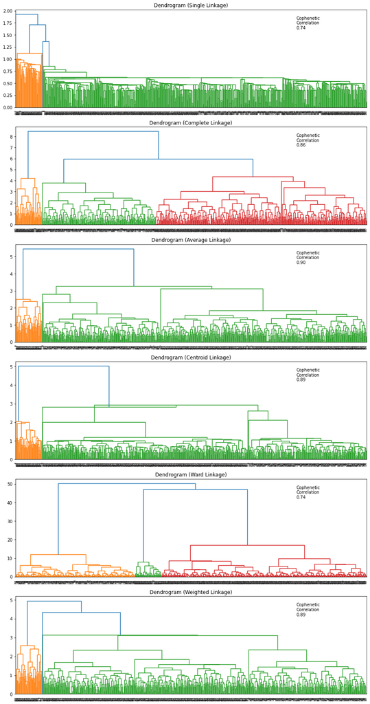

```python
# list of linkage methods
linkage_methods = ["single", "complete", "average", "centroid", "ward", "weighted"]

# lists to save results of cophenetic correlation calculation
compare_cols = ["Linkage", "Cophenetic Coefficient"]

# to create a subplot image
fig, axs = plt.subplots(len(linkage_methods), 1, figsize=(15, 30))

# We will enumerate through the list of linkage methods above
# For each linkage method, we will plot the dendrogram and calculate the cophenetic correlation
for i, method in enumerate(linkage_methods):
    Z = linkage(DataScaled, metric="euclidean", method=method)

    dendrogram(Z, ax=axs[i])
    axs[i].set_title(f"Dendrogram ({method.capitalize()} Linkage)")

    coph_corr, coph_dist = cophenet(Z, pdist(DataScaled))
    axs[i].annotate(
        f"Cophenetic\nCorrelation\n{coph_corr:0.2f}",
        (0.80, 0.80),
        xycoords="axes fraction",
    )
```

- Average Linkage has the highest cophenetic correlation among the linkage methods.
- 3 appears to be the appropriate number of clusters from the dendrogram for average linkage

#### Cluster Profiling

```python
HCmodel = AgglomerativeClustering(n_clusters=3, affinity="euclidean", linkage="average")
HCmodel.fit(DataScaled)
```

```
AgglomerativeClustering(linkage='average', n_clusters=3)
```

```python
DataScaled["HC_Clusters"] = HCmodel.labels_
data["HC_Clusters"] = HCmodel.labels_
```

```python
cluster_profile_HC = data.groupby("HC_Clusters").mean()
```

#### Favorate is K-means:

- K-means was more clear in choosing the number of clusters
- Vizualizations available to K-means are easier to interpret and use.

#### Pros of Heirachial Clustering:

- Heirachial clustering was good for picking a linkage type
- Shows cophenetic correlation

#### Heirachial

```python
# lets display cluster profile
cluster_profile_HC.style.highlight_max(color="lightgreen", axis=0)
```

| HC_Clusters | Avg_Credit_Limit | Total_Credit_Cards | Total_visits_bank | Total_visits_online | Total_calls_made | K_means_segments |
| --- | --- | --- | --- | --- | --- | --- |
| 0 | 33713.178295 | 5.511628 | 3.485788 | 0.984496 | 2.005168 | 0.002584 |
| 1 | 141040.000000 | 8.740000 | 0.600000 | 10.900000 | 1.080000 | 2.000000 |
| 2 | 12197.309417 | 2.403587 | 0.928251 | 3.560538 | 6.883408 | 1.000000 |

#### K-means

```python
# lets display cluster profile
cluster_profile.style.highlight_max(color="green", axis=0)
```

| K_means_segments | Avg_Credit_Limit | Total_Credit_Cards | Total_visits_bank | Total_visits_online | Total_calls_made | count_in_each_segment |
| --- | --- | --- | --- | --- | --- | --- |
| 0 | 33782.383420 | 5.515544 | 3.489637 | 0.981865 | 2.000000 | 386 |
| 1 | 12174.107143 | 2.410714 | 0.933036 | 3.553571 | 6.870536 | 224 |
| 2 | 141040.000000 | 8.740000 | 0.600000 | 10.900000 | 1.080000 | 50 |

#### Observation

- Cluster 0 from both clustering methods is grouped similar.
- Clusters 1 and 2 looked switched between the two methods.
- It appears both methods came to the same conclusion when assighed to 3 clusters.

### Action Statement

The three clusters is judged by the k-means method. Our three groups of customers is shown below.

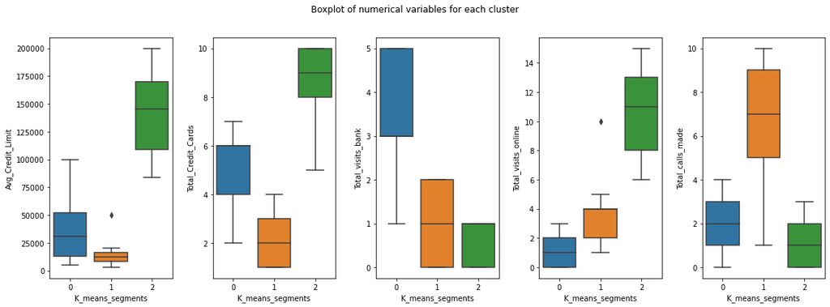

```python
fig, axes = plt.subplots(1, 5, figsize=(16, 6))
fig.suptitle("Boxplot of numerical variables for each cluster")
counter = 0
for ii in range(5):
    sns.boxplot(ax=axes[ii], y=data[num_col[counter]], x=data["K_means_segments"])
    counter = counter + 1

fig.tight_layout(pad=2.0)
```

#### Observation:

Cluster 0:

- Credit limit mean is between the 50% and 75% quartile (18000 to 48000).
- Total cards owned are between 4 and 6 (between 25% and 75% quartile)
- Visits to Bank are between 3 and 5 (top 50%)
- Visits to Online are between 0 and 2 (bottom 50%)
- Total Calls made are between 1 and 3 (bottom 50)

Cluster 1:

- Credit limit mean is less than $25000
- Total cards owned are between 1 and 3 (below 25% quartile)
- Visits to Bank are between 0 and 2 (bottom 50%)
- Visits to Online are between 2 and 4 (between the the 50% and 75% quartile)
- Total Calls made are between 5 and 9 (upper 50%)

#### Market Conclusion:

Cluster 2 is the most satisfied because they have the highest credit card limit and repeatedly purchase the most credit cards.No marketing should be done on phone calls because they are the least satisfied. Most sales should be done at the bank. Online banking seems to build higher credit card limits without the need for more cards. Therefore, they lower dependency on credit card ownership. Since cluster 1 owns the least cards they need to be targeted for upselling so they can join the model group, cluster 2, which makes the bank the most revenu. Finding ways to encourage in person banking will increase sales.

#### Service Conclusion:

The customer service team should focus on improving the call service because the most unsatisfied customers are calling. Online services should guide the customers through the online portal with them to help introduce/encourage online banking because the most successful customers are banking online.